# TP1 — Análisis y visualización (SAIJ)

**Consigna oficial:** `prácticos/TP1.md` del repo del mentor. Entrega original 07/08 (vencida).  
**Este notebook:** bloque estructurado + relojes temporales. Texto y reporte visual van en D2.

**Datos:** muestra oficial `datos/dataset_sample.jsonl.gz` (~8.7k filas). **No** es el corpus completo de HuggingFace.  
**Sala limpia:** no se copia el TP del grupo. Las cifras de acá valen solo para esta muestra.

Preguntas que este bloque tiene que poder responder (notebook cerrado):

1. ¿Qué es una fila?
2. ¿Cuál es el candidato a target y por qué todavía no está cerrado?
3. ¿Qué reloj temporal no hay que usar como “fecha del fallo”?
4. ¿Dónde hay sesgo geográfico / de tribunal / de clase que un modelo podría memorizar?

## 0. Carga

```python
from pathlib import Path
import json
import gzip
import re
from collections import Counter

import numpy as np
import pandas as pd
import matplotlib.pyplot as plt
import seaborn as sns

sns.set_theme(style="whitegrid")
plt.rcParams["figure.figsize"] = (10, 4)

ROOT = Path("../..")
SAMPLE = ROOT / "datos" / "dataset_sample.jsonl.gz"
assert SAMPLE.exists(), f"Falta la muestra oficial: {SAMPLE}"

df = pd.read_json(SAMPLE, lines=True, compression="gzip")
print(f"filas={len(df):,}  columnas={df.shape[1]}  archivo={SAMPLE.name}")
df.head(2)
```

```
filas=8,748  columnas=71  archivo=dataset_sample.jsonl.gz
```

|  | numero-sumario | materia | sumario | descriptores | referencias-normativas | texto | fuente | analista | responsable | fecha | ... | status | titulo_noticia | destacada | fecha_newsletter | suplemento_bo | subtipo | url_portal | nro_orden | fecha_destacada | sigla_emisor |
| --- | --- | --- | --- | --- | --- | --- | --- | --- | --- | --- | --- | --- | --- | --- | --- | --- | --- | --- | --- | --- | --- |
| 0 | None | NaN | NaN | {'descriptor': [{'elegido': {'termino': 'Térmi... | None | NaN | NaN | NaN | NaN | None | ... | NaN | NaN | NaN | NaN | NaN | NaN | NaN | NaN | NaN | NaN |
| 1 | C0005865 | CIVIL | [[p]]LOCACION DE INMUEBLES-CONVENIO DE DESOCUP... | {'descriptor': [{'elegido': {'termino': 'locac... | {'referencia-normativa': [{'cr': None, 'id': '... | [[p]]Si bien el art. 47 de la ley 21.342 estab... | OFICIAL | NaN | NaN | 1990-03-26 | ... | NaN | NaN | NaN | NaN | NaN | NaN | NaN | NaN | NaN | NaN |

2 rows × 71 columns

## 1. Unidad de análisis

`guid` vino único en la muestra. Eso **no** prueba que cada fila sea un fallo judicial: puede haber plantillas, novedades y sumarios mezclados.

Hipótesis a chequear: el prefijo de `id-infojus` distingue tipos de registro (p.ej. sumario vs fallo vs novedad). No lo damos por sentado hasta ver cobertura de campos.

```python
def nonempty(s: pd.Series) -> pd.Series:
    if s.dtype == object:
        return s.notna() & s.map(lambda v: v not in ("", {}, []))
    return s.notna()

n_nonnull = df.apply(nonempty).sum(axis=1)
print("campos no nulos por fila: min/mediana/max =",
      int(n_nonnull.min()), int(n_nonnull.median()), int(n_nonnull.max()))
print("filas con <=3 campos no nulos:", int((n_nonnull <= 3).sum()))

# En esta muestra TODOS los guid están anonimizados con prefijo 123456789.
# No filtrar por eso. La plantilla de esquema es la fila casi vacía con texto dummy en descriptores.
print("guid únicos:", df["guid"].nunique(dropna=False), "de", len(df))
print("guid anonimizado (prefijo 123456789):",
      float(df["guid"].astype(str).str.startswith("123456789").mean()))

def _desc_dump(v):
    return json.dumps(v, ensure_ascii=False) if isinstance(v, (dict, list)) else str(v)

dummy = df["descriptores"].map(_desc_dump).str.contains("Término elegido para describir", na=False)
print("filas con descriptores de plantilla:", int(dummy.sum()))
work = df.loc[~dummy].copy()
print("filas de trabajo:", len(work))
print("guid únicos:", work["guid"].nunique(dropna=False), "de", len(work))
print("id-infojus no nulos / únicos:",
      int(work["id-infojus"].notna().sum()),
      work["id-infojus"].nunique(dropna=True))
```

```
campos no nulos por fila: min/mediana/max = 2 23 30
filas con <=3 campos no nulos: 1035
guid únicos: 8748 de 8748
guid anonimizado (prefijo 123456789): 1.0
```

```
filas con descriptores de plantilla: 1035
filas de trabajo: 7713
guid únicos: 7713 de 7713
id-infojus no nulos / únicos: 7713 7713
```

```python
ids = work["id-infojus"].dropna().astype(str)
prefix = ids.str.slice(0, 2)
print("prefijos id-infojus (n=2):")
print(prefix.value_counts(dropna=False).head(10))

work["id_prefix"] = work["id-infojus"].astype(str).str.slice(0, 2)
work.loc[work["id-infojus"].isna(), "id_prefix"] = "<NA>"

cov_cols = ["materia", "sumario", "texto", "tribunal", "tipo-tribunal",
            "provincia", "fecha", "timestamp", "titulo_noticia"]
rows = []
for pref, g in work.groupby("id_prefix"):
    rec = {"prefix": pref, "n": len(g)}
    for c in cov_cols:
        rec[c] = float(nonempty(g[c]).mean())
    rows.append(rec)
coverage = pd.DataFrame(rows).sort_values("n", ascending=False)
coverage
```

```
prefijos id-infojus (n=2):
id-infojus
SU    4851
FA    2859
NV       3
Name: count, dtype: int64
```

|  | prefix | n | materia | sumario | texto | tribunal | tipo-tribunal | provincia | fecha | timestamp | titulo_noticia |
| --- | --- | --- | --- | --- | --- | --- | --- | --- | --- | --- | --- |
| 2 | SU | 4851 | 1.0 | 1.0 | 0.999794 | 0.0 | 0.996908 | 0.998351 | 1.0 | 1.000000 | 0.0 |
| 0 | FA | 2859 | 0.0 | 0.0 | 0.000000 | 1.0 | 0.997901 | 1.000000 | 1.0 | 0.613851 | 0.0 |
| 1 | NV | 3 | 0.0 | 0.0 | 0.000000 | 0.0 | 0.000000 | 1.000000 | 1.0 | 0.000000 | 1.0 |

Si un prefijo tiene `materia`/`sumario` y otro tiene `tribunal`/`tipo-fallo`, **no son la misma unidad**. Mezclarlos en un conteo de fueros miente.

Las columnas `titulo_noticia` / `org_emisor` / `tipo-norma` parecen de otro esquema (novedad/norma). En esta muestra deberían ser residuales.

## 2. Esquema, tipos y anidados

```python
def describe_col(series: pd.Series) -> dict:
    types = series.map(lambda v: type(v).__name__ if v is not None and not (isinstance(v, float) and pd.isna(v)) else "NA")
    vc = types.value_counts()
    nested = series.map(lambda v: isinstance(v, (dict, list))).mean()
    return {
        "n_non_na": int(series.notna().sum()),
        "pct_na": round(float(series.isna().mean()), 3),
        "types": vc.to_dict(),
        "pct_nested": round(float(nested), 3),
        "nunique_approx": series.dropna().astype(str).nunique(),
    }

schema = pd.DataFrame({c: describe_col(work[c]) for c in work.columns}).T
schema.sort_values("pct_na")
```

|  | n_non_na | pct_na | types | pct_nested | nunique_approx |
| --- | --- | --- | --- | --- | --- |
| id_prefix | 7713 | 0.0 | {'str': 7713} | 0.0 | 3 |
| guid | 7713 | 0.0 | {'str': 7713} | 0.0 | 7713 |
| id-infojus | 7713 | 0.0 | {'str': 7713} | 0.0 | 7713 |
| jurisdiccion | 7711 | 0.0 | {'dict': 7708, 'str': 3, 'NA': 2} | 0.999 | 7 |
| fecha | 7713 | 0.0 | {'str': 7712, 'int': 1} | 0.0 | 4752 |
| ... | ... | ... | ... | ... | ... |
| esq-clasificacion | 0 | 1.0 | {'NA': 7713} | 0.0 | 0 |
| disidencia | 0 | 1.0 | {'NA': 7713} | 0.0 | 0 |
| control-constitucional | 0 | 1.0 | {'NA': 7713} | 0.0 | 0 |
| d_link | 3 | 1.0 | {'NA': 7710, 'dict': 3} | 0.0 | 3 |
| seq | 3 | 1.0 | {'NA': 7710, 'float': 3} | 0.0 | 3 |

72 rows × 5 columns

```python
# Peek de estructuras anidadas (sin aplanar todavía)
for col in ["descriptores", "jurisdiccion", "referencias-normativas", "sumarios-relacionados"]:
    sample = next((v for v in work[col] if isinstance(v, dict)), None)
    print(f"\n=== {col} keys ===")
    if sample is None:
        print("sin dict en la muestra")
    else:
        print(sorted(sample.keys()))
        print(json.dumps(sample, ensure_ascii=False)[:500], "...")
```

```
=== descriptores keys ===
['descriptor', 'suggest']
{"descriptor": [{"elegido": {"termino": "locación de inmuebles"}, "preferido": {"termino": "Obligaciones y contratos/Contratos/contratos civiles/locación/locación de inmuebles"}, "sinonimos": {"termino": ["arrendamiento", "contrato de locación", "locaciones urbanas"]}}, {"elegido": {"termino": "conv…

=== jurisdiccion keys ===
['capital', 'codigo', 'descripcion', 'id-pais']
{"codigo": "NACIONAL", "descripcion": "Nacional", "capital": "Nacional", "id-pais": 11} ...

=== referencias-normativas keys ===
['referencia-normativa']
{"referencia-normativa": [{"cr": null, "id": "REFERENCIAS_NORMATIVAS_0", "ref": "LEY C 021342 0000 00 00 0047 000 0000 000"}, {"cr": "INCISO 1", "id": "REFERENCIAS_NORMATIVAS_1", "ref": "CPC C 017454 1981 08 18 0684 000 0000 000"}]} ...

=== sumarios-relacionados keys ===
['sumario-relacionado']
{"sumario-relacionado": "C1010142"} ...
```

`descriptores` y `jurisdiccion` anidados: **no** contar nulos como si fueran un string. Aplanar es decisión de TP2. En TP1 solo se diagnostica.

## 3. Candidato a target (aún no cerrado)

```python
mat = work["materia"].dropna().astype(str)
print("materia no nula:", len(mat), f"({len(mat)/len(work):.1%} de filas de trabajo)")
print("valores únicos de materia:", mat.nunique())
print("\nTop 20:")
print(mat.value_counts().head(20))
```

```
materia no nula: 4851 (62.9% de filas de trabajo)
valores únicos de materia: 282

Top 20:
materia
PROCESAL                     684
PENAL                        527
LABORAL                      483
CIVIL                        459
CIVIL - COMERCIAL            419
ADMINISTRATIVO               288
CONSTITUCIONAL               205
COMERCIAL                    202
CIVIL-COMERCIAL              202
PENAL-PROCESAL                98
PROCESAL-PENAL                83
SEGURIDAD SOCIAL              80
PROCESAL-CIVIL                79
CONSTITUCIONAL-PROCESAL       63
PROCESAL - PENAL              57
CONSTITUCIONAL - PROCESAL     39
TRIBUTARIO                    37
CIVIL-PROCESAL                35
PROCESAL-LABORAL              29
CONTRAVENCIONAL               29
Name: count, dtype: int64
```

```python
FUERO_TOKENS = [
    "CIVIL", "COMERCIAL", "PENAL", "LABORAL", "ADMINISTRATIVO",
    "CONSTITUCIONAL", "TRIBUTARIO", "ADUANERO", "AGRARIO",
    "FAMILIA", "MENORES", "PREVISIONAL",
]
token_rows = []
for m in mat:
    parts = set(re.split(r"[^A-Za-zÁÉÍÓÚáéíóúÑñ]+", m.upper()))
    hit = sorted(t for t in FUERO_TOKENS if t in parts)
    token_rows.append(",".join(hit) if hit else "<sin token de fuero>")
print("¿cuántos tokens de fuero aparecen en materia?")
print(pd.Series(token_rows).value_counts().head(25))
print("\n¿materia con más de un token de fuero?",
      sum("," in x for x in token_rows))
print("¿materia sin token de fuero?",
      sum(x == "<sin token de fuero>" for x in token_rows))
```

```
¿cuántos tokens de fuero aparecen en materia?
<sin token de fuero>             891
PENAL                            798
CIVIL,COMERCIAL                  675
CIVIL                            621
LABORAL                          539
CONSTITUCIONAL                   367
ADMINISTRATIVO                   338
COMERCIAL                        246
CONSTITUCIONAL,PENAL              64
TRIBUTARIO                        53
CIVIL,CONSTITUCIONAL              36
ADMINISTRATIVO,CONSTITUCIONAL     33
CONSTITUCIONAL,LABORAL            28
CIVIL,LABORAL                     20
ADMINISTRATIVO,CIVIL              19
COMERCIAL,CONSTITUCIONAL          15
CONSTITUCIONAL,TRIBUTARIO         13
ADMINISTRATIVO,LABORAL            10
CIVIL,PENAL                       10
ADMINISTRATIVO,COMERCIAL           7
ADUANERO                           7
PENAL,TRIBUTARIO                   7
ADMINISTRATIVO,TRIBUTARIO          6
ADMINISTRATIVO,PENAL               5
CIVIL,COMERCIAL,LABORAL            5
Name: count, dtype: int64

¿materia con más de un token de fuero? 990
¿materia sin token de fuero? 891
```

**Hipótesis (no receta):** el proyecto pide predecir **fuero/rama**. `materia` es el campo más cercano, pero:

- hay valores que no son fuero (`PROCESAL`);
- hay combinaciones (`CIVIL - COMERCIAL`, `CIVIL-COMERCIAL` con distinto separador);
- una parte de las filas no tiene `materia`.

Cerrar el target hoy sería mentir. TP1 pide **identificarlo**, no entrenar.

Leakage a no olvidar: si el target se construye desde `materia`, **no** puede entrar `materia` (ni descriptores que la parafrasean) como feature cuando el README pide predecir *leyendo el sumario*.

## 4. Tribunales, provincias, desbalance

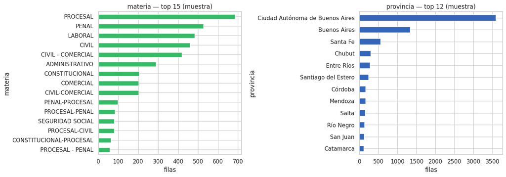

```
tipo-tribunal únicos: 139
tipo-tribunal
CS    2877
CC    1048
LB     565
PN     555
CO     462
CI     359
NP     284
LM     249
CA     221
CT     109
CM      99
SS      98
Name: count, dtype: int64

instancia:
instancia
C                    4526
S                    2970
T                      49
J                      47
NaN                    31
S S                    29
X                      20
S S S                  11
C C                    11
S S S S                 5
C C C                   4
S S S S S S S S S       3
Name: count, dtype: int64
```

```python
fig, axes = plt.subplots(1, 2, figsize=(14, 5))
mat.value_counts().head(15).iloc[::-1].plot.barh(ax=axes[0], color="#3b6")
axes[0].set_title("materia — top 15 (muestra)")
axes[0].set_xlabel("filas")

work["provincia"].dropna().value_counts().head(12).iloc[::-1].plot.barh(ax=axes[1], color="#36b")
axes[1].set_title("provincia — top 12 (muestra)")
axes[1].set_xlabel("filas")
plt.tight_layout()
plt.show()

print("tipo-tribunal únicos:", work["tipo-tribunal"].nunique(dropna=True))
print(work["tipo-tribunal"].value_counts(dropna=False).head(12))
print("\ninstancia:")
print(work["instancia"].value_counts(dropna=False).head(12))
```

CABA + Buenos Aires dominan. `tipo-tribunal` es código (`CS`, `CC`, …) y hay 100+ valores: no es un fuero limpio. Un modelo que use provincia/tribunal puede “acertar” por sesgo institucional, no por el texto.

## 5. Relojes temporales

Candidatos: `fecha` (documento), `fecha-alta` / `fecha-mod` (administrativos), `timestamp` / `timestamp-m` / `timestamp-alta` (epoch).

Un pico en `timestamp` **no** es, por sí solo, más fallos emitidos ese año.

```python
print("fecha tipos:", work["fecha"].map(lambda v: type(v).__name__).value_counts().to_dict())
print("fecha con pipe | :", int(work["fecha"].astype(str).str.contains(r"\|", na=False).sum()))
print("ejemplos con pipe:")
print(work.loc[work["fecha"].astype(str).str.contains(r"\|", na=False), "fecha"].head(8).tolist())

work["fecha_str"] = work["fecha"].map(lambda v: None if pd.isna(v) else str(v))
work["n_fechas_en_campo"] = work["fecha_str"].map(
    lambda s: len(s.split("|")) if isinstance(s, str) else np.nan
)
work["fecha_primera"] = pd.to_datetime(
    work["fecha_str"].map(lambda s: s.split("|")[0] if isinstance(s, str) else None),
    errors="coerce",
)
print("\nfecha_primera parseada:", int(work["fecha_primera"].notna().sum()),
      "min", work["fecha_primera"].min(), "max", work["fecha_primera"].max())
```

```
fecha tipos: {'str': 7712, 'int': 1}
fecha con pipe | : 166
ejemplos con pipe:
['1992-04-28|1991-03-19|1991-08-20|1993-03-30', '1994-04-05|1992-02-18|1991-04-16', '2006-12-19|2007-05-31', '1994-06-10|1996-04-10', '1991-02-15|1994-12-15|1995-05-23|1993-07-08', '1996-12-10|1999-05-27', '1995-10-11|1996-08-06|1993-09-21', '1993-11-08|1994-02-07']

fecha_primera parseada: 7712 min 1865-06-27 00:00:00 max 2026-03-30 00:00:00
```

```python
# timestamp: valores ~1e12 → milisegundos. Pandas puede meter el mínimo de int64 en nulos.
ts = pd.to_numeric(work["timestamp"], errors="coerce")
sentinel = ts <= 0
print("timestamp nulos/sentinel:", int(ts.isna().sum() + sentinel.sum()),
      "plausibles (>0):", int((ts > 0).sum()))
ts = ts.mask(ts <= 0)
print("timestamp min/max (ms):", ts.min(), ts.max())
work["ts_alta_dt"] = pd.to_datetime(ts, unit="ms", errors="coerce", utc=True)
print("timestamp como datetime utc min/max:",
      work["ts_alta_dt"].min(), work["ts_alta_dt"].max())

fa = pd.to_datetime(work["fecha-alta"], errors="coerce", utc=True)
print("fecha-alta parseada:", int(fa.notna().sum()), fa.min(), fa.max())
work["fecha_alta_dt"] = fa
```

```
timestamp nulos/sentinel: 1107 plausibles (>0): 6606
timestamp min/max (ms): 1344416452000.0 1777472756000.0
timestamp como datetime utc min/max: 2012-08-08 09:00:52+00:00 2026-04-29 14:25:56+00:00
fecha-alta parseada: 7709 1995-04-27 00:00:00+00:00 2026-04-29 00:00:00+00:00
```

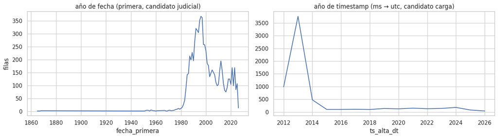

```
filas con ambos relojes: 6606
mismo año doc vs timestamp: 12.4%
doc más viejo que timestamp (esperado si timestamp es carga): 6606
```

```python
fig, axes = plt.subplots(1, 2, figsize=(14, 4), sharey=False)
work["fecha_primera"].dt.year.value_counts().sort_index().plot(
    ax=axes[0], title="año de fecha (primera, candidato judicial)"
)
axes[0].set_ylabel("filas")
work["ts_alta_dt"].dt.year.value_counts().sort_index().plot(
    ax=axes[1], title="año de timestamp (ms → utc, candidato carga)"
)
plt.tight_layout()
plt.show()

# ¿coinciden año judicial y año de carga?
cmp = work.dropna(subset=["fecha_primera", "ts_alta_dt"]).copy()
cmp["year_doc"] = cmp["fecha_primera"].dt.year
cmp["year_ts"] = cmp["ts_alta_dt"].dt.year
print("filas con ambos relojes:", len(cmp))
if len(cmp):
    same = float((cmp["year_doc"] == cmp["year_ts"]).mean())
    print(f"mismo año doc vs timestamp: {same:.1%}")
    doc = cmp["fecha_primera"]
    if getattr(doc.dt, "tz", None) is None:
        doc = doc.dt.tz_localize("UTC")
    older = int((doc < cmp["ts_alta_dt"]).sum())
    print("doc más viejo que timestamp (esperado si timestamp es carga):", older)
```

## 6. Hallazgos preliminares (muestra, no corpus)

Escribir en voz alta, no como verdad del SAIJ completo:

- Hay **más de un tipo de registro** en el mismo JSONL (prefijos de `id-infojus` + cobertura de campos distinta).
- `materia` es el mejor **candidato** a origen del target, y está sucio (combinaciones, `PROCESAL`, nulos).
- Geografía sesgada a CABA/PBA.
- `fecha` a veces trae **varias** fechas en un string. `timestamp` está en **milisegundos**.
- Los dos relojes no cuentan la misma historia: no usar timestamp como fecha del fallo.

## Checkpoint oral (cerrá el notebook)

1. ¿Qué evidencia tenés de que una fila no es siempre un fallo?
2. ¿Por qué no congelarías hoy el target como `materia` cruda?
3. ¿Qué feature institucional sería leakage si el objetivo es predecir fuero *desde el sumario*?
4. ¿Qué reloj usarías para una serie de “actividad judicial” y cuál no?